# Geração de Números Aleatórios - Método da Rejeição

Prof. Lupercio F. Bessegato

12/10/2020

## Método da Rejeição

Há ocasiões em que o método da transformação inversa ou mesmo as transformações gerais não poderão ser usado para construir geradores de números aleatórios de muitas distribuições. Nesse casos, recorremos a métodos indiretos; ou seja, métodos nos quais geramos uma variável aleatória candidata e testamo a solução candidata para acaeitá-la ou não. Essa classe de métodos é bastante poderosa e nos permitirá simular praticamente qualquer distribuição. Dentre esses, os métodos de Aceitação/Rejeição exigem apenas que conheçamos a forma funcional da densidade $f$ de interesse (chamada densidade alvo). Usamos uma densidade $g$, cuja simulação é mais simples e que é denominada densidade candidata. Ela será usada para gerar a variável aleatória de interesse. As únicas restrições impostas a esta densidade candidata $g$ são:

1. $f$ e $g$ devem ter suportes compatíveis, ou seja, $g(x) > 0$, quando $f(x) > 0$.
2. Há uma constante $M$ com $\frac{f(x)}{g(x)} \leq M$ para $\forall x$

Neste caso, podemos contruir um gerador de números aleatórios da variável de $f_X$ usando o procedimento a seguir. Primeiramente geramos $Y \sim g_Y$ e, independentemente, geramos $U \sim \mathcal{Unif.}(0, 1)$. Se
$$U \leq \frac{1}{M}\frac{f_X(Y)}{g_Y(Y)},$$

então $X = Y$ Se a desigualdade não for satisfeita, descarta-se $Y$ e $U$ e tenta-se novamente, com o mesmo procedimento.

Resumidamente, o método de Aceitação/Rejeição pode ser representado no pseudocódigo a seguir:

**Algoritmo - Método de Aceitação/Rejeição**

1. Gerar $Y \sim g_Y$ e $U \sim \mathcal{Unif.}(0,1)$.
2. Aceitar $X = Y$, se $U f_X(Y) \leq M g_X(Y)$.
3. Caso contrário, retornar ao passo 1.

Por exemplo, queremos gerar números da variável aleatória com função de densidade de probabilidade alvo dada por:

$$f_X(x) = \begin{cases}
\frac{2}{\sqrt{2\pi}} \operatorname{e}^{- \frac{x^2}{2}} &
\text{, } \quad x \geq 0 \\
0 &\text{, }\quad x<0
\end{cases}$$

Uma função candidata $g$ é função de densidade exponencial padrão que tem o mesmo suporte de $f$ e é fácil de simular (sua inversa é bastante simples). Sua densidade é:
$$g_Y(y) = \begin{cases}
\operatorname{e}^{- y} &
\text{, } \quad x \geq 0 \\
0 &\text{, }\quad x<0
\end{cases}$$
Temos de determinar o valor da constante $M$. Na realidade queremos que um múltiplo de $g$ esteja sempre envolvendo a função alvo $f$. A razão entre as funções alvo e candidata são:
$$\frac{f_X(x)}{g_Y(x)} = \frac{\frac{2}{\sqrt{2\pi}} \operatorname{e}^{- \frac{x^2}{2}}}{\operatorname{e}^{-x}} =
\frac{2}{\sqrt{2\pi}} \operatorname{e}^{x - \frac{x^2}{2}}$$

O máximo é atingido quando a derivada desta razão é zero, ou seja:
$$\frac{\operatorname{d}}{\operatorname{d} \! x}
\left( \frac{f_X(x)}{g_Y(x)} \right) =
\frac{2}{\sqrt{2\pi}}(1 - x) \operatorname{e}^{x - \frac{x^2}{2}} ,$$

que é zero, para $x = 1$. O ponto crítico então será:
$$\frac{f_x(1)}{g_Y(1)}= \frac{2}{\sqrt{2\pi}} \operatorname{e}^{1 - \frac{1}{2}} =
\frac{2}{\sqrt{2\pi}} \operatorname{e}^{\frac{1}{2}},$$

logo,
$$\frac{f_x(x)}{g_Y(x)} \leq \frac{2}{\sqrt{2\pi}} \operatorname{e}^{\frac{1}{2}}=M
\text{ , }
\quad \forall x$$
Observe o gráfico da densidade alvo e da candidata ajustada pela constante $M$

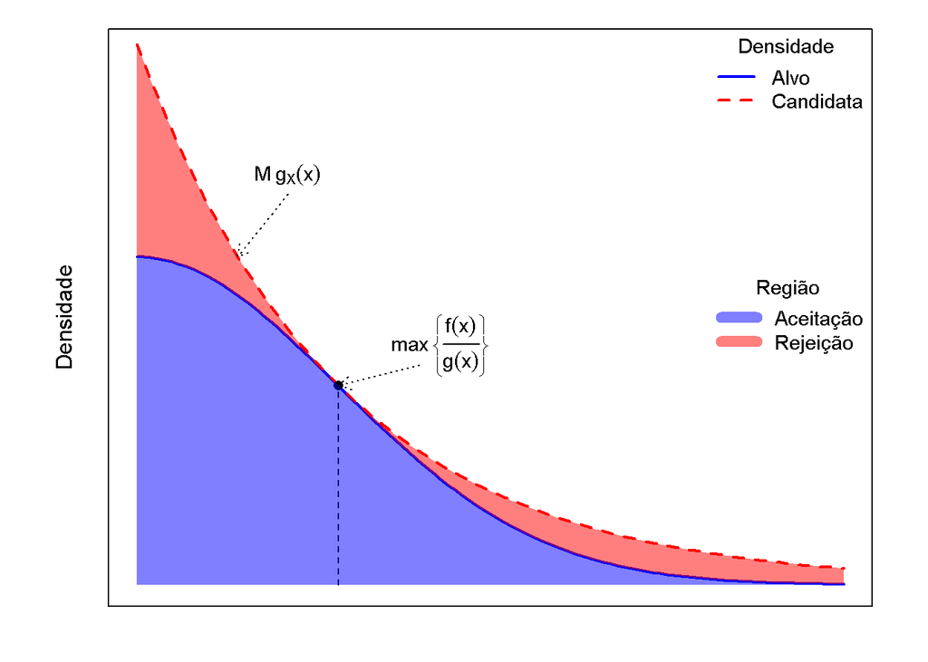

Neste caso a estrutura do algoritmo será

```
while(f.X <= Y){
    U = runif(1)
    V = runif(1)
    X = - log(U)
    Y = V * exp(-X) * M
}
```

Nessa estrutura `exp(-X) * M` é $M \, g_Y(X)$ e se $V = 1$, $Y$ está situado na envoltória. Tentem implementar.